# Project 2: Simulating a Random Process

2025, Rayhan R. Zamzamy, et al.

In this experiment, we simulate and analyze random processes using R. A random process is a sequence of random variables indexed by time. We explore different types of random signals—such as white noise, autoregressive (AR), and moving average (MA) processes—by examining their time-domain behavior, autocorrelation structure, and power spectral density (PSD).

## Preparation

For cross-correlation reference, we use white Gaussian noise process with mean 0 and standard deviation 1.

```r
# Set the seed for reproducibility
set.seed(52)
```

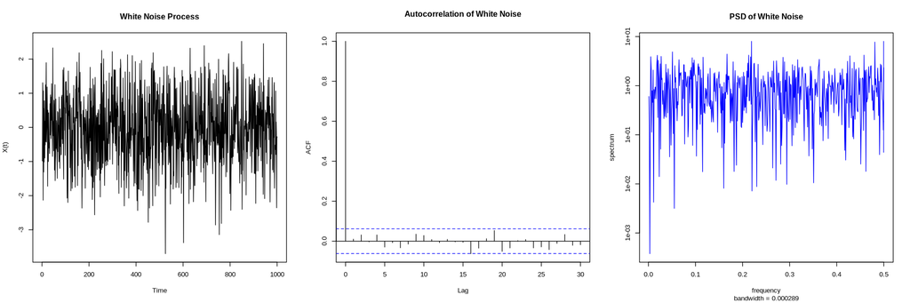

```r
# White Noise as reference
n <- 1000
wn <- rnorm(n, mean = 0, sd = 1)

input_fft <- fft(wn) # FFT for cross-PSD

# --- Plots
par(mfrow=c(1,3))
options(repr.plot.width = 15, repr.plot.height = 5)

plot.ts(wn, main = "White Noise Process", ylab = "X(t)")
acf(wn, main = "Autocorrelation of White Noise")
spectrum(wn, main = "PSD of White Noise", col = "blue")
```

## 1. Moving Average Process: MA(2)

We simulate a Moving Average process of order 2, defined as:

$$ X(t) = w(t) + 0.6w(t - 1) + 0.3w(t - 2) $$

Where $ w(t) \sim \mathcal{N}(0, 1) $. This process uses past noise terms, but not past values of the process itself. It is useful for modeling systems where past random shocks affect current values for a short memory window.

```
== Summary Statistics for MA(2) ==
  Quantity   Simulated Theoretical
1     Mean -0.05911882        0.00
2    Power  1.28875388        1.45

== ACF Comparison ==
  Lag ACF_Simulated ACF_Theoretical
1   0        1.0000          1.0000
2   1        0.5001          0.5379
3   2        0.1296          0.2069
4   3       -0.0727          0.0000

== CCF Comparison (Lags -3 to 3) ==
  Lag CCF_Simulated CCF_Theoretical
1  -3       -0.0087             0.0
2  -2       -0.0391             0.0
3  -1       -0.0319             0.6
4   0       -0.0240             0.3
5   1        0.0062             0.0
6   2        0.0043             0.0
7   3       -0.0279             0.0

== PSD Comparison (First 5 Freq) ==
   Freq PSD_Sim PSD_Theo
1 0.001  0.5417   3.6100
2 0.002  0.4499   3.6099
3 0.003  3.6281   3.6097
4 0.004  0.9683   3.6093
5 0.005  4.1324   3.6088

== Cross-PSD Comparison (First 5 Freq) ==
   Freq CrossPSD_Sim CrossPSD_Theo
1 0.000       2.2297        1.9000
2 0.001       1.1511        1.9000
3 0.002       0.6672        1.8999
4 0.003       0.0864        1.8998
5 0.004       0.4383        1.8997
```

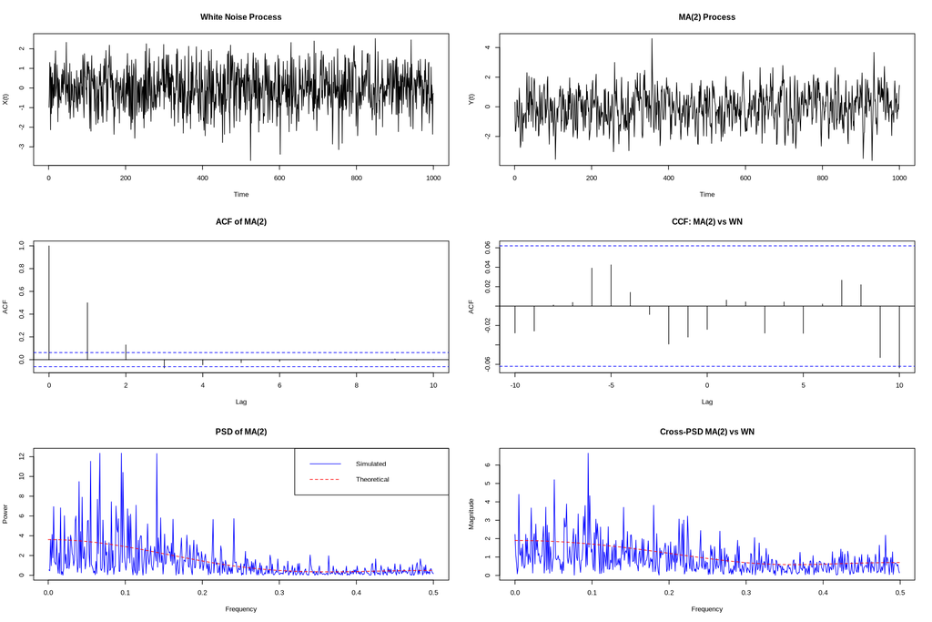

```r
# ---- MA(2) ----
theta_ma2 <- c(0.6, 0.3)
ma2 <- arima.sim(n = n, list(ma = theta_ma2))

# --- Stats
mean_ma2 <- mean(ma2)
power_ma2 <- mean(ma2^2)
power_ma2_theo <- 1 + sum(theta_ma2^2)

# --- ACF
acf_ma2_sim <- acf(ma2, lag.max = 10, plot = FALSE)$acf[,,1]
acf_ma2_theo <- numeric(11)
acf_ma2_theo[1] <- 1
acf_ma2_theo[2] <- (theta_ma2[1] + theta_ma2[1]*theta_ma2[2]) / power_ma2_theo
acf_ma2_theo[3] <- theta_ma2[2] / power_ma2_theo

# --- CCF
ccf_ma2 <- ccf(wn, ma2, lag.max = 10, plot = FALSE)$acf[,,1]
ccf_theo_ma2 <- c(0, 0, theta_ma2[1], theta_ma2[2], 0, 0, 0)

# --- PSD
omega <- seq(0, pi, length.out = 512)
H_ma2 <- 1 + theta_ma2[1]*exp(-1i*omega*1) + theta_ma2[2]*exp(-1i*omega*2)
psd_ma2_theo <- Mod(H_ma2)^2
spec_ma2_sim <- spectrum(ma2, plot = FALSE)

# --- Cross PSD
output_fft_ma2 <- fft(ma2)
cross_psd_sim <- input_fft * Conj(output_fft_ma2) / n
half <- 1:(n/2)
freqs <- (0:(n-1)) / n
cross_psd_sim_mag <- Mod(cross_psd_sim[half])
cross_psd_theo <- Mod(Conj(H_ma2))

# --- Plots
par(mfrow = c(3, 2))
options(repr.plot.width = 15, repr.plot.height = 10)

plot.ts(wn, main = "White Noise Process", ylab = "X(t)")
plot.ts(ma2, main = "MA(2) Process", ylab = "Y(t)")
acf(ma2, lag.max = 10, main = "ACF of MA(2)")
ccf(wn, ma2, lag.max = 10, main = "CCF: MA(2) vs WN")
plot(spec_ma2_sim$freq, spec_ma2_sim$spec, type = "l", col = "blue",
     main = "PSD of MA(2)", xlab = "Frequency", ylab = "Power")
lines(omega/(2*pi), psd_ma2_theo, col = "red", lty = 2)
legend("topright", legend = c("Simulated", "Theoretical"), col = c("blue", "red"), lty = 1:2)
plot(freqs[half], cross_psd_sim_mag, type = "l", col = "blue",
     main = "Cross-PSD MA(2) vs WN", xlab = "Frequency", ylab = "Magnitude")
lines(omega/(2*pi), cross_psd_theo, col = "red", lty = 2)

# --- Tables
summary_ma2 <- data.frame(
  Quantity = c("Mean", "Power"),
  Simulated = c(mean_ma2, power_ma2),
  Theoretical = c(0, power_ma2_theo)
)

acf_table_ma2 <- data.frame(
  Lag = 0:3,
  ACF_Simulated = round(acf_ma2_sim[1:4], 4),
  ACF_Theoretical = round(acf_ma2_theo[1:4], 4)
)

psd_table_ma2 <- data.frame(
  Freq = round(spec_ma2_sim$freq[1:5], 4),
  PSD_Sim = round(spec_ma2_sim$spec[1:5], 4),
  PSD_Theo = round(psd_ma2_theo[1:5], 4)
)

ccf_table_ma2 <- data.frame(
  Lag = -3:3,
  CCF_Simulated = round(ccf_ma2[8:14], 4),  # middle 7 values
  CCF_Theoretical = round(ccf_theo_ma2, 4)
)

cross_psd_table_ma2 <- data.frame(
  Freq = round(freqs[half][1:5], 4),
  CrossPSD_Sim = round(cross_psd_sim_mag[1:5], 4),
  CrossPSD_Theo = round(cross_psd_theo[1:5], 4)
)

cat("\n== Summary Statistics for MA(2) ==\n")
print(summary_ma2)
cat("\n== ACF Comparison ==\n")
print(acf_table_ma2)
cat("\n== CCF Comparison (Lags -3 to 3) ==\n")
print(ccf_table_ma2)
cat("\n== PSD Comparison (First 5 Freq) ==\n")
print(psd_table_ma2)
cat("\n== Cross-PSD Comparison (First 5 Freq) ==\n")
print(cross_psd_table_ma2)
```

## 2. Moving Average Process: MA(3)

We simulate a Moving Average process of order 3, defined as:

$$ X(t) = w(t) + 0.9w(t - 1) + 0.6w(t - 2) + 0.3w(t - 3) $$

Where $ w(t) \sim \mathcal{N}(0, 1) $. This process extends the MA(2) by incorporating an additional lag of white noise. As with other MA models, the process does not depend on its own past values, only on recent noise terms.

```
== Summary Statistics for MA(3) ==
  Quantity   Simulated Theoretical
1     Mean -0.01913241        0.00
2    Power  2.19584157        2.26

== ACF Comparison ==
  Lag ACF_Simulated ACF_Theoretical
1   0        1.0000          1.0000
2   1        0.7141          0.7168
3   2        0.3809          0.3850
4   3        0.1420          0.1327
5   4        0.0082          0.0000

== CCF Comparison (Lags -3 to 3) ==
  Lag CCF_Simulated CCF_Theoretical
1  -3       -0.0045             0.0
2  -2       -0.0195             0.0
3  -1       -0.0325             0.9
4   0       -0.0288             0.6
5   1       -0.0670             0.3
6   2       -0.0719             0.0
7   3       -0.0653             0.0

== PSD Comparison (First 5 Freq) ==
   Freq PSD_Sim PSD_Theo
1 0.001  1.1559   7.8400
2 0.002 19.5883   7.8397
3 0.003  5.0581   7.8388
4 0.004 36.0202   7.8373
5 0.005  0.1630   7.8353

== Cross-PSD Comparison (First 5 Freq) ==
   Freq CrossPSD_Sim CrossPSD_Theo
1 0.000       0.7216        2.8000
2 0.001       1.7374        2.7999
3 0.002       1.3987        2.7998
4 0.003       0.1273        2.7995
5 0.004       2.1881        2.7992
```

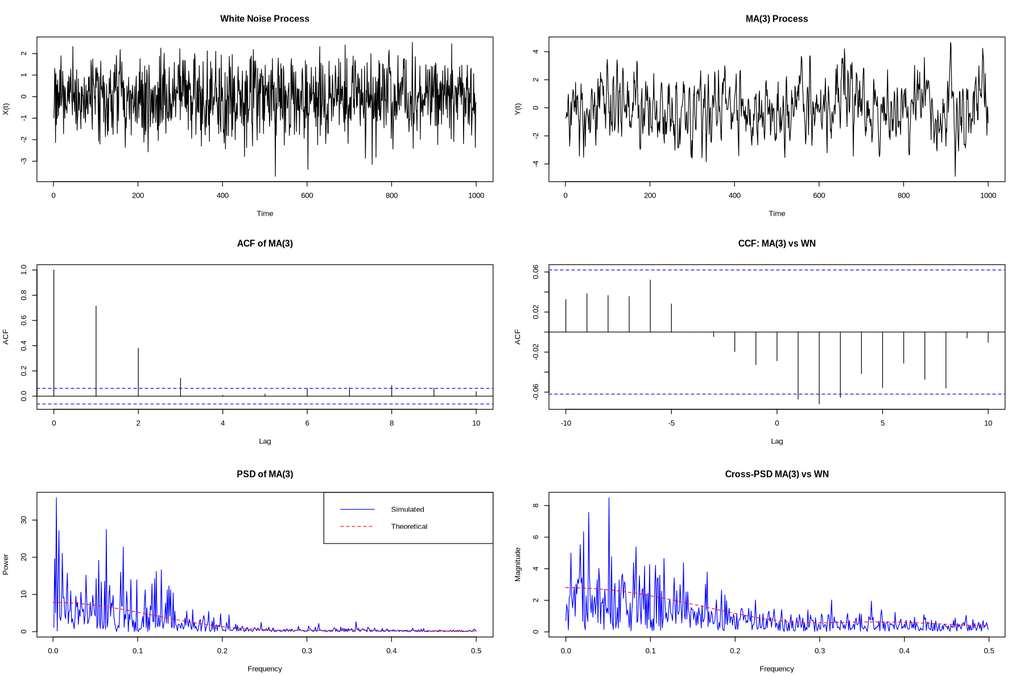

```r
# ---- MA(3) ----
theta_ma3 <- c(0.9, 0.6, 0.3)
ma3 <- arima.sim(n = n, list(ma = theta_ma3))

# --- Basic Stats
mean_ma3 <- mean(ma3)
power_ma3 <- mean(ma3^2)
power_ma3_theo <- 1 + sum(theta_ma3^2)

# --- ACF
acf_ma3_sim <- acf(ma3, lag.max = 10, plot = FALSE)$acf[,,1]
acf_ma3_theo <- numeric(11)
acf_ma3_theo[1] <- 1
acf_ma3_theo[2] <- (theta_ma3[1] + theta_ma3[1]*theta_ma3[2] + theta_ma3[2]*theta_ma3[3]) / power_ma3_theo
acf_ma3_theo[3] <- (theta_ma3[2] + theta_ma3[1]*theta_ma3[3]) / power_ma3_theo
acf_ma3_theo[4] <- theta_ma3[3] / power_ma3_theo

# --- CCF
ccf_ma3 <- ccf(wn, ma3, lag.max = 10, plot = FALSE)$acf[,,1]
ccf_theo_ma3 <- c(0, 0, theta_ma3[1], theta_ma3[2], theta_ma3[3], 0, 0)  # lags -3 to 3

# --- PSD
H_ma3 <- 1 +
  theta_ma3[1]*exp(-1i*omega*1) +
  theta_ma3[2]*exp(-1i*omega*2) +
  theta_ma3[3]*exp(-1i*omega*3)
psd_ma3_theo <- Mod(H_ma3)^2
spec_ma3_sim <- spectrum(ma3, plot = FALSE)

# --- Cross PSD
output_fft_ma3 <- fft(ma3)
cross_psd_sim_ma3 <- input_fft * Conj(output_fft_ma3) / n
cross_psd_sim_mag_ma3 <- Mod(cross_psd_sim_ma3[half])
cross_psd_theo_ma3 <- Mod(Conj(H_ma3))

# --- Plots
par(mfrow = c(3, 2))
options(repr.plot.width = 15, repr.plot.height = 10)

plot.ts(wn, main = "White Noise Process", ylab = "X(t)")
plot.ts(ma3, main = "MA(3) Process", ylab = "Y(t)")
acf(ma3, lag.max = 10, main = "ACF of MA(3)")
ccf(wn, ma3, lag.max = 10, main = "CCF: MA(3) vs WN")
plot(spec_ma3_sim$freq, spec_ma3_sim$spec, type = "l", col = "blue",
     main = "PSD of MA(3)", xlab = "Frequency", ylab = "Power")
lines(omega/(2*pi), psd_ma3_theo, col = "red", lty = 2)
legend("topright", legend = c("Simulated", "Theoretical"), col = c("blue", "red"), lty = 1:2)
plot(freqs[half], cross_psd_sim_mag_ma3, type = "l", col = "blue",
     main = "Cross-PSD MA(3) vs WN", xlab = "Frequency", ylab = "Magnitude")
lines(omega/(2*pi), cross_psd_theo_ma3, col = "red", lty = 2)

# --- Tables
summary_ma3 <- data.frame(
  Quantity = c("Mean", "Power"),
  Simulated = c(mean_ma3, power_ma3),
  Theoretical = c(0, power_ma3_theo)
)

acf_table_ma3 <- data.frame(
  Lag = 0:4,
  ACF_Simulated = round(acf_ma3_sim[1:5], 4),
  ACF_Theoretical = round(acf_ma3_theo[1:5], 4)
)

psd_table_ma3 <- data.frame(
  Freq = round(spec_ma3_sim$freq[1:5], 4),
  PSD_Sim = round(spec_ma3_sim$spec[1:5], 4),
  PSD_Theo = round(psd_ma3_theo[1:5], 4)
)

ccf_table_ma3 <- data.frame(
  Lag = -3:3,
  CCF_Simulated = round(ccf_ma3[8:14], 4),
  CCF_Theoretical = round(ccf_theo_ma3, 4)
)

cross_psd_table_ma3 <- data.frame(
  Freq = round(freqs[half][1:5], 4),
  CrossPSD_Sim = round(cross_psd_sim_mag_ma3[1:5], 4),
  CrossPSD_Theo = round(cross_psd_theo_ma3[1:5], 4)
)

cat("\n== Summary Statistics for MA(3) ==\n")
print(summary_ma3)
cat("\n== ACF Comparison ==\n")
print(acf_table_ma3)
cat("\n== CCF Comparison (Lags -3 to 3) ==\n")
print(ccf_table_ma3)
cat("\n== PSD Comparison (First 5 Freq) ==\n")
print(psd_table_ma3)
cat("\n== Cross-PSD Comparison (First 5 Freq) ==\n")
print(cross_psd_table_ma3)
```

## 3. Autoregressive Process: AR(1)

Now we simulate an Autoregressive process of order 1, defined as:

$$ X(t) = 0.8X(t - 1) + w(t) $$

Where $ w(t) \sim \mathcal{N}(0, 1) $. Unlike Moving Average processes, the AR(1) process relies on its own past value, introducing recursive dependence. This model is appropriate for capturing inertia or persistence in time series, where the current value tends to follow the previous value with some decay over time.

```
== Summary Statistics for AR(1) ==
  Quantity  Simulated Theoretical
1     Mean 0.04000902    0.000000
2    Power 2.88128048    2.777778

== ACF Comparison ==
  Lag ACF_Simulated ACF_Theoretical
1   0        1.0000           1.000
2   1        0.8074           0.800
3   2        0.6637           0.640
4   3        0.5519           0.512

== CCF Comparison (Lags -3 to 3) ==
  Lag CCF_Simulated CCF_Theoretical
1  -3        0.0565               0
2  -2        0.0335               0
3  -1        0.0261               0
4   0        0.0267               0
5   1        0.0337               0
6   2        0.0398               0
7   3        0.0055               0

== PSD Comparison (First 5 Freq) ==
   Freq PSD_Sim PSD_Theo
1 0.001 10.8005  25.0000
2 0.002  3.4121  24.9811
3 0.003 14.0263  24.9246
4 0.004 10.4746  24.8311
5 0.005 25.7434  24.7013

== Cross-PSD Comparison (First 5 Freq) ==
   Freq CrossPSD_Sim CrossPSD_Theo
1 0.000       1.5090        5.0000
2 0.001       5.8201        4.9981
3 0.002       1.7183        4.9925
4 0.003       0.3004        4.9831
5 0.004       0.9243        4.9700
```

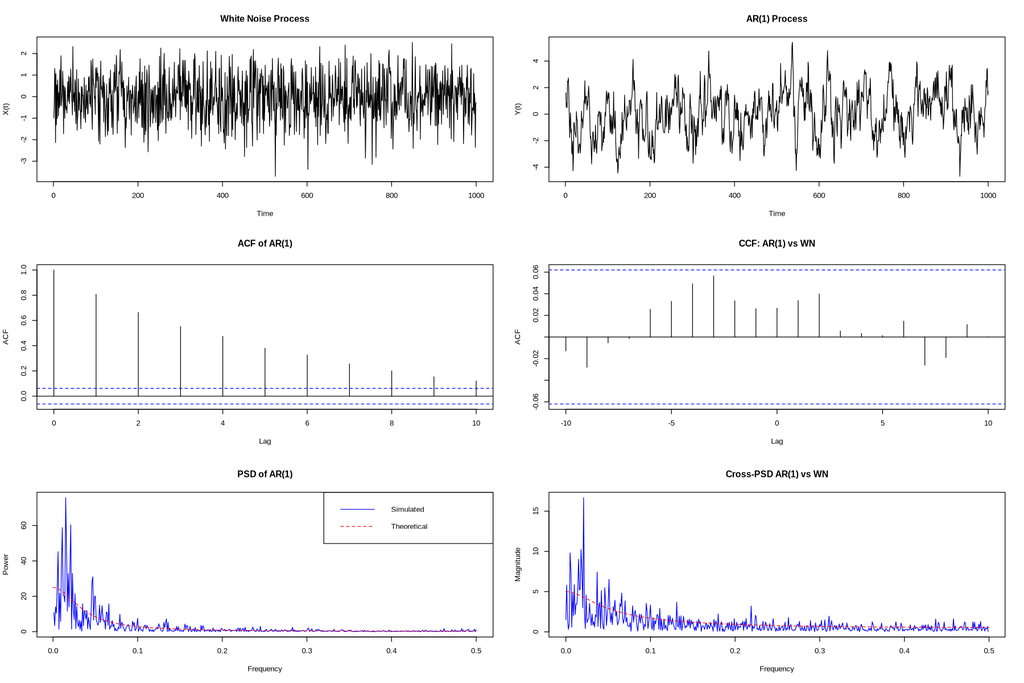

```r
# ---- AR(1) ----
phi_ar1 <- 0.8
ar1 <- arima.sim(n = n, list(ar = phi_ar1))

# --- Basic Stats
mean_ar1 <- mean(ar1)
power_ar1 <- mean(ar1^2)
power_ar1_theo <- 1 / (1 - phi_ar1^2)

# --- ACF
acf_ar1_sim <- acf(ar1, lag.max = 10, plot = FALSE)$acf[,,1]
acf_ar1_theo <- phi_ar1^(0:10)

# --- CCF
ccf_ar1 <- ccf(wn, ar1, lag.max = 10, plot = FALSE)$acf[,,1]
ccf_theo_ar1 <- rep(0, 7)  # no theoretical CCF available

# --- PSD
H_ar1 <- 1 / (1 - phi_ar1 * exp(-1i * omega))
psd_ar1_theo <- Mod(H_ar1)^2
spec_ar1_sim <- spectrum(ar1, plot = FALSE)

# --- Cross PSD
output_fft_ar1 <- fft(ar1)
cross_psd_sim_ar1 <- input_fft * Conj(output_fft_ar1) / n
cross_psd_sim_mag_ar1 <- Mod(cross_psd_sim_ar1[half])
cross_psd_theo_ar1 <- Mod(Conj(H_ar1))

# --- Plots
par(mfrow = c(3, 2))
options(repr.plot.width = 15, repr.plot.height = 10)

plot.ts(wn, main = "White Noise Process", ylab = "X(t)")
plot.ts(ar1, main = "AR(1) Process", ylab = "Y(t)")
acf(ar1, lag.max = 10, main = "ACF of AR(1)")
ccf(wn, ar1, lag.max = 10, main = "CCF: AR(1) vs WN")
plot(spec_ar1_sim$freq, spec_ar1_sim$spec, type = "l", col = "blue",
     main = "PSD of AR(1)", xlab = "Frequency", ylab = "Power")
lines(omega/(2*pi), psd_ar1_theo, col = "red", lty = 2)
legend("topright", legend = c("Simulated", "Theoretical"), col = c("blue", "red"), lty = 1:2)
plot(freqs[half], cross_psd_sim_mag_ar1, type = "l", col = "blue",
     main = "Cross-PSD AR(1) vs WN", xlab = "Frequency", ylab = "Magnitude")
lines(omega/(2*pi), cross_psd_theo_ar1, col = "red", lty = 2)

# --- Tables
summary_ar1 <- data.frame(
  Quantity = c("Mean", "Power"),
  Simulated = c(mean_ar1, power_ar1),
  Theoretical = c(0, power_ar1_theo)
)

acf_table_ar1 <- data.frame(
  Lag = 0:3,
  ACF_Simulated = round(acf_ar1_sim[1:4], 4),
  ACF_Theoretical = round(acf_ar1_theo[1:4], 4)
)

psd_table_ar1 <- data.frame(
  Freq = round(spec_ar1_sim$freq[1:5], 4),
  PSD_Sim = round(spec_ar1_sim$spec[1:5], 4),
  PSD_Theo = round(psd_ar1_theo[1:5], 4)
)

ccf_table_ar1 <- data.frame(
  Lag = -3:3,
  CCF_Simulated = round(ccf_ar1[8:14], 4),
  CCF_Theoretical = round(ccf_theo_ar1, 4)
)

cross_psd_table_ar1 <- data.frame(
  Freq = round(freqs[half][1:5], 4),
  CrossPSD_Sim = round(cross_psd_sim_mag_ar1[1:5], 4),
  CrossPSD_Theo = round(cross_psd_theo_ar1[1:5], 4)
)

cat("\n== Summary Statistics for AR(1) ==\n")
print(summary_ar1)
cat("\n== ACF Comparison ==\n")
print(acf_table_ar1)
cat("\n== CCF Comparison (Lags -3 to 3) ==\n")
print(ccf_table_ar1)
cat("\n== PSD Comparison (First 5 Freq) ==\n")
print(psd_table_ar1)
cat("\n== Cross-PSD Comparison (First 5 Freq) ==\n")
print(cross_psd_table_ar1)
```

## Summary

This project focused on simulating and analyzing random processes, specifically:

- **White Noise Process**: Served as a baseline random process with zero mean and unit variance.
- **Moving Average Processes (MA(2) and MA(3))**: Modeled as linear combinations of white noise terms with specified coefficients.
- **Autoregressive Process (AR(1))**: Modeled as a linear function of its previous value plus a white noise term.

For each process, we:

- Simulated time series data.
- Computed and plotted the Autocorrelation Function (ACF) and Power Spectral Density (PSD).
- Calculated theoretical ACF and PSD for comparison.
- Evaluated Cross-Correlation Function (CCF) and Cross-PSD between input and output where applicable.